# Digital progress—for whom? – presentation

## Digital progress—for whom?

We thought we knew which country would lead.

Then we changed the age group.

Nokwanele Pretty Gwebu and Kay-Lee Dramat  
Age and digital skills in Europe

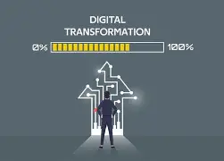

## “Where did the thing I copied go?”

You explain it.  
They try again.

Perhaps you take the phone and do it.

**What happens when you aren’t there?**

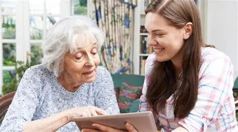

Illustrative image supplied by the authors.

## We expected Estonia to stand out

Our starting assumption

After reading about Estonia’s digital reputation, we thought we had a fairly good idea of what we would find.

**Apparently, the data had other plans.**

We compared reported digital activities across age groups, using Eurostat’s basic or above-basic digital-skills indicator.

## Among younger adults, the result fitted our expectations

At ages 25–34, Estonia’s estimate is about 86%, compared with about 70% in Germany. 2025.

Eurostat · isoc_sk_dskl_i21 · I_DSK2_BAB · percentage of individuals

## Then we looked at older adults

At ages 65–74, Germany’s estimate is about 41%, compared with about 20% in Estonia. 2025.

Eurostat · isoc_sk_dskl_i21 · I_DSK2_BAB · percentage of individuals

## Was 2025 just an unusual year?

We checked 2021 and 2023. The comparison reverses in all three years. Estonia leads at ages 25–34. Germany leads at ages 65–74.

[figure not shown]

Eurostat · isoc_sk_dskl_i21 · I_DSK2_BAB · percentage of individuals

## Then we looked beyond our two-country comparison

[figure not shown]

27 countries.  
Six age groups.  
One question:

**Who shares in digital progress?**

Youngest age group inside.  
Oldest outside.  
Colour shows percentages.

Eurostat · 2025 · Equal-sized segments do not represent population sizes.

## How much of this pattern appears across Europe?

In all 27 countries, the older group’s estimate is lower. But the gaps differ. ● Ages 25–34 ● Ages 65–74 · 2025

[figure not shown]

Eurostat · isoc_sk_dskl_i21 · I_DSK2_BAB · percentage of individuals

## The same age group tells very different national stories

Among adults aged 65–74, estimates range from 7.3% in Romania to 69.6% in Ireland. 2025.

Eurostat · isoc_sk_dskl_i21 · I_DSK2_BAB · percentage of individuals

## Back to the person asking for help

This time, it’s an appointment they need to book.

The form is online.

The person who usually helps is unavailable.

**What would they need to complete it themselves?**

An imagined situation connecting the topic to everyday life. Eurostat does not measure reliance on family help here.

## There are places where someone can ask for help

Germany: Sparkasse Leipzig + VHS Nordsachsen

Free online-banking training for older adults.

Practical guidance, safe use and time for questions.

Documented example: Oschatz, March 2026.

[figure not shown]

Banking-help image supplied by the authors; the pictured event is unverified.

[Source: Sparkasse Leipzig, 12 March 2026](https://www.sparkasse-leipzig.de/de/home/ihre-sparkasse/pressecenter/details.html?news=v1m8271)

## Support also exists in Estonia and Romania

Estonia: Tallinn Libraries

Free individual and group digital guidance for seniors, including email, online purchases and payments.

Romania: Hi Digital, Vodafone Foundation

Free practical workshops for adults aged 65+, covering smartphones, online payments and safety.

[Tallinn Libraries](https://tallinnaraamatukogud.ee/onnelik-ja-nutikas-seenior/) · [Vodafone Foundation Romania](https://fundatia-vodafone.ro/proiecte/hi-digital/)  
Examples of available support, not evidence that the national gaps have closed.

## So, whose experience counts as digital progress?

What changed our minds

Estonia’s lead over Germany reversed when we changed the age group.

That reversal appeared in all three years.

Across Europe, older adults’ results also differed widely between countries.

**The gaps are real. So are the places offering help.**

What would make that help easier to find for someone in your family?

## Data and limits

Eurostat: **Individuals’ level of digital skills**  
`isoc_sk_dskl_i21` · `I_DSK2_BAB` · `PC_IND`

Reported activities, rather than a direct skills test.  
Group estimates; ages 75+ outside our selection.  
Descriptive comparisons without causal or significance claims.

[Data source](https://ec.europa.eu/eurostat/databrowser/view/isoc_sk_dskl_i21/default/table?lang=en) · Accompanying report